# Data624 Assignment7

Ritesh Lohiya

April 4, 2019

# Data624 Assignment 7

```r
suppressMessages(suppressWarnings(library(fpp2)))
suppressMessages(suppressWarnings(library(readxl)))
suppressMessages(suppressWarnings(library(seasonal)))
suppressMessages(suppressWarnings(library(rdatamarket)))
suppressMessages(suppressWarnings(library(tseries)))
suppressMessages(suppressWarnings(library(AppliedPredictiveModeling)))
suppressMessages(suppressWarnings(library(fma)))
suppressMessages(suppressWarnings(library(corrplot)))
suppressMessages(suppressWarnings(library(caret)))
suppressMessages(suppressWarnings(library(pls)))
suppressMessages(suppressWarnings(library(glmnet)))
suppressMessages(suppressWarnings(library(missForest)))
set.seed(3)
```

#### 6.2 Developing a model to predict permeability (see Sect. 1.4) could save significant resources for a pharmaceutical company, while at the same time more rapidly identifying molecules that have a sufficient permeability to become a drug:

#### (a) Start R and use these commands to load the data:

```r
data(permeability)
#permeability
summary(permeability)
```

```
##   permeability
##  Min.   : 0.06
##  1st Qu.: 1.55
##  Median : 4.91
##  Mean   :12.24
##  3rd Qu.:15.47
##  Max.   :55.60
```

#### The matrix fingerprints contains the 1,107 binary molecular predic-tors for the 165 compounds, while permeability contains permeability response.

#### (b) The fingerprint predictors indicate the presence or absence of substructures of a molecule and are often sparse meaning that relatively few of the molecules contain each substructure. Filter out the predictors that have low frequencies using the nearZeroVar function from the caret package. How many predictors are left for modeling?

```r
nz <- nearZeroVar(fingerprints)
length(nz)
```

```
## [1] 719
```

```r
# Filter predictors
fp <- fingerprints[, -nz]
```

#### 719 predictors can be dropped because they have near zero variance. So now there are 388 predictors.

#### (c) Split the data into a training and a test set, pre-process the data, and tune a PLS model. How many latent variables are optimal and what is the corresponding resampled estimate of R2?

```r
cp <- cor(fp)
#cp
```

#### Lets remove the predictors with high correlation(.9)

```r
cp_high <- findCorrelation(cp, cutoff = .9)
fp <- fp[, -cp]
```

#### Now lets do the train test split and build the model

```r
# train and test split

fp_train <- fp[1:124, ]
fp_test <- fp[1:124, ]

permeability_train <- permeability[1:124, ]
permeability_test <- permeability[1:124, ]
```

#### PLS Model

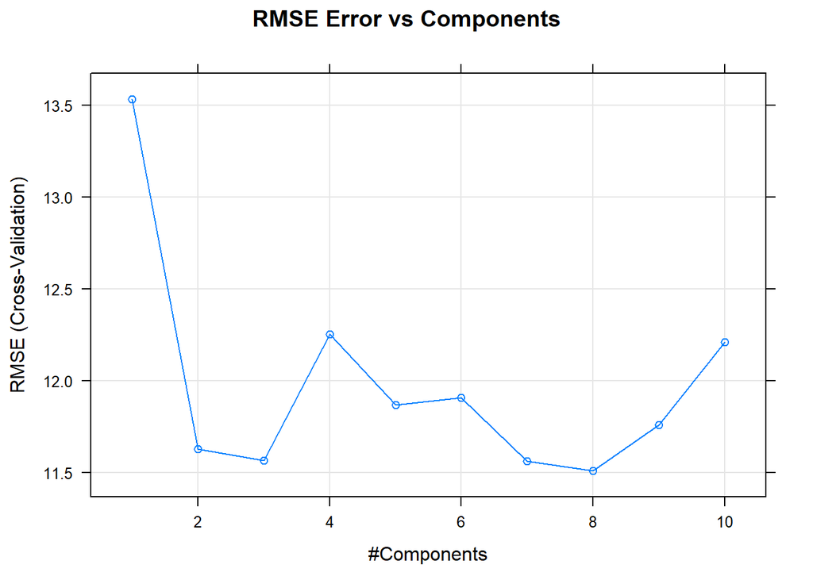

```r
pls_model <- train(fp_train, permeability_train,
                method = "pls",
                tuneLength = 10,
                trControl = trainControl(method = "cv"))


# Plot PLS Model

plot(pls_model, main="RMSE Error vs Components")
```

```r
pls_model$results[pls_model$results$ncomp == 8, 'Rsquared']
```

```
## [1] 0.4928981
```

```r
pls_model$results[pls_model$results$ncomp == 8, 'RMSE']
```

```
## [1] 11.50874
```

```r
pls_model
```

```
## Partial Least Squares
##
## 124 samples
## 387 predictors
##
## No pre-processing
## Resampling: Cross-Validated (10 fold)
## Summary of sample sizes: 111, 112, 111, 112, 112, 112, ...
## Resampling results across tuning parameters:
##
##   ncomp  RMSE      Rsquared   MAE
##    1     13.53374  0.2972899  10.277374
##    2     11.62831  0.4346302   8.471991
##    3     11.56626  0.4597054   8.868359
##    4     12.25383  0.4306803   9.592441
##    5     11.86676  0.4589821   8.836670
##    6     11.90645  0.4643249   8.993007
##    7     11.56075  0.4839172   9.052520
##    8     11.50874  0.4928981   8.957240
##    9     11.75846  0.4741684   9.017795
##   10     12.20983  0.4497406   9.398011
##
## RMSE was used to select the optimal model using the smallest value.
## The final value used for the model was ncomp = 8.
```

#### R^2 value is 0.4928981 and RMSE is 11.50874 with n = 8

#### (d) Predict the response for the test set. What is the test set estimate of R2?

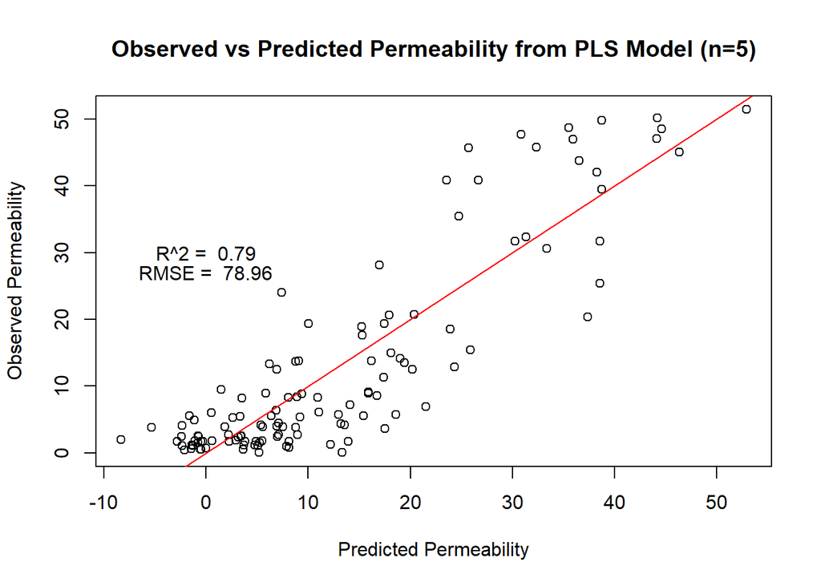

```r
# Predict the permeability based on test set of fingerprints

permeability_predict = predict(pls_model, fp_test)

# Print out predictions and outcomes

plot(permeability_predict, permeability_test, main="Observed vs Predicted Permeability from PLS Model (n=5)", xlab="Predicted Permeability", ylab="Observed Permeability")

abline(0, 1, col='red')
text(0, 30, paste("R^2 = ", round(cor(permeability_test, permeability_predict)^2, 2)))
text(0, 27, paste("RMSE = ", round(sqrt(sum((permeability_test - permeability_predict)^2)), 2)))
```

#### The R^2 value is .79 which is really good.

#### (e) Try building other models discussed in this chapter. Do any have better predictive performance?

#### Lets use glmnet to build a new model.

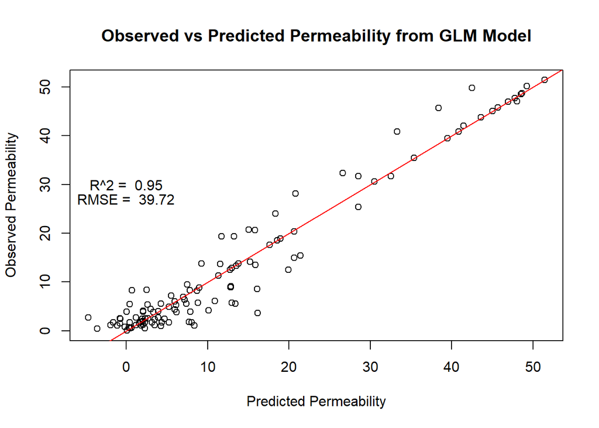

```r
glm_model <- glmnet(fp_train, permeability_train, family="gaussian", alpha=0.5, lambda=0.001)
permeability_glm_predict <- predict(glm_model, fp_test)

plot(permeability_glm_predict, permeability_test, main="Observed vs Predicted Permeability from GLM Model", xlab="Predicted Permeability", ylab="Observed Permeability")

abline(0, 1, col='red')
text(0, 30, paste("R^2 = ", round(cor(permeability_test, permeability_glm_predict)^2, 2)))
text(0, 27, paste("RMSE = ", round(sqrt(sum((permeability_test - permeability_glm_predict)^2)), 2)))
```

#### (f) Would you recommend any of your models to replace the permeability laboratory experiment?

#### I would recommend GLM Net model because it has a very high R^2.

#### 6.3 . A chemical manufacturing process for a pharmaceutical product was discussed in Sect. 1.4. In this problem, the objective is to understand the relationship between biological measurements of the raw materials (predictors), 6.5 Computing 139 measurements of the manufacturing process (predictors), and the response of product yield. Biological predictors cannot be changed but can be used to assess the quality of the raw material before processing. On the other hand, manufacturing process predictors can be changed in the manufacturing process. Improving product yield by 1 % will boost revenue by approximately one hundred thousand dollars per batch:

#### (a) Start R and use these commands to load the data:

```r
data(chemicalManufacturing)
```

#### Name of the data is ChemicalManufacturingProcess

```r
data(ChemicalManufacturingProcess)
#ChemicalManufacturingProcess
summary(ChemicalManufacturingProcess)
```

```
##      Yield       BiologicalMaterial01 BiologicalMaterial02
##  Min.   :35.25   Min.   :4.580        Min.   :46.87
##  1st Qu.:38.75   1st Qu.:5.978        1st Qu.:52.68
##  Median :39.97   Median :6.305        Median :55.09
##  Mean   :40.18   Mean   :6.411        Mean   :55.69
##  3rd Qu.:41.48   3rd Qu.:6.870        3rd Qu.:58.74
##  Max.   :46.34   Max.   :8.810        Max.   :64.75
##
##  BiologicalMaterial03 BiologicalMaterial04 BiologicalMaterial05
##  Min.   :56.97        Min.   : 9.38        Min.   :13.24
##  1st Qu.:64.98        1st Qu.:11.24        1st Qu.:17.23
##  Median :67.22        Median :12.10        Median :18.49
##  Mean   :67.70        Mean   :12.35        Mean   :18.60
##  3rd Qu.:70.43        3rd Qu.:13.22        3rd Qu.:19.90
##  Max.   :78.25        Max.   :23.09        Max.   :24.85
##
##  BiologicalMaterial06 BiologicalMaterial07 BiologicalMaterial08
##  Min.   :40.60        Min.   :100.0        Min.   :15.88
##  1st Qu.:46.05        1st Qu.:100.0        1st Qu.:17.06
##  Median :48.46        Median :100.0        Median :17.51
##  Mean   :48.91        Mean   :100.0        Mean   :17.49
##  3rd Qu.:51.34        3rd Qu.:100.0        3rd Qu.:17.88
##  Max.   :59.38        Max.   :100.8        Max.   :19.14
##
##  BiologicalMaterial09 BiologicalMaterial10 BiologicalMaterial11
##  Min.   :11.44        Min.   :1.770        Min.   :135.8
##  1st Qu.:12.60        1st Qu.:2.460        1st Qu.:143.8
##  Median :12.84        Median :2.710        Median :146.1
##  Mean   :12.85        Mean   :2.801        Mean   :147.0
##  3rd Qu.:13.13        3rd Qu.:2.990        3rd Qu.:149.6
##  Max.   :14.08        Max.   :6.870        Max.   :158.7
##
##  BiologicalMaterial12 ManufacturingProcess01 ManufacturingProcess02
##  Min.   :18.35        Min.   : 0.00          Min.   : 0.00
##  1st Qu.:19.73        1st Qu.:10.80          1st Qu.:19.30
##  Median :20.12        Median :11.40          Median :21.00
##  Mean   :20.20        Mean   :11.21          Mean   :16.68
##  3rd Qu.:20.75        3rd Qu.:12.15          3rd Qu.:21.50
##  Max.   :22.21        Max.   :14.10          Max.   :22.50
##                       NA's   :1              NA's   :3
```

[output cut: 105 more lines]

```
##  Min.   : 0.00          Min.   : 0.0000        Min.   :0.000
##  1st Qu.:11.40          1st Qu.: 0.6000        1st Qu.:1.800
##  Median :11.60          Median : 0.8000        Median :1.900
##  Mean   :11.21          Mean   : 0.9119        Mean   :1.805
##  3rd Qu.:11.70          3rd Qu.: 1.0250        3rd Qu.:1.900
##  Max.   :12.10          Max.   :11.0000        Max.   :2.100
##
##  ManufacturingProcess45
##  Min.   :0.000
##  1st Qu.:2.100
##  Median :2.200
##  Mean   :2.138
##  3rd Qu.:2.300
##  Max.   :2.600
##
```

#### (b) A small percentage of cells in the predictor set contain missing values. Use an imputation function to fill in these missing values (e.g., see Sect. 3.8).

#### We see some missing values from the summary and will impute them using missForest.

```r
cmfp = missForest(ChemicalManufacturingProcess)
```

```
##   missForest iteration 1 in progress...
```

```
## done!
##   missForest iteration 2 in progress...
```

```
## done!
##   missForest iteration 3 in progress...
```

```
## done!
```

```r
cmfp = cmfp$ximp
```

#### Next we will separate out target variable yield from rest of the predictors

```r
cmfp_data = cmfp[,2:58]
target = cmfp[,1]
```

#### (c) Split the data into a training and a test set, pre-process the data, and tune a model of your choice from this chapter. What is the optimal value of the performance metric?

#### In this problem lets try 75/ 25 split.

```r
train = createDataPartition(target, p=0.75 )
predictor_train = cmfp_data[train$Resample1,]
target_train = target[train$Resample]
predictor_test = cmfp_data[-train$Resample1,]
target_test = target[-train$Resample1]
```

#### PLS model

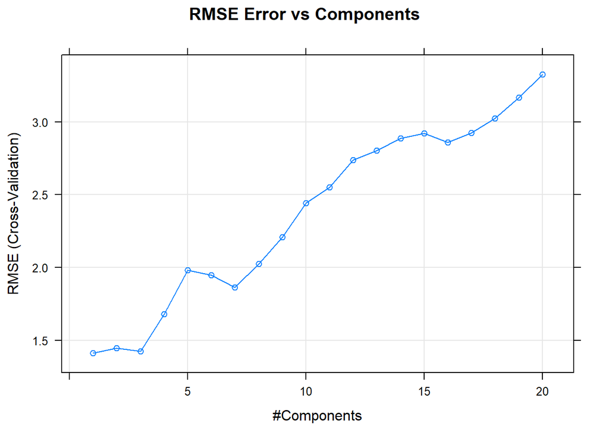

```r
pls_model <- train(predictor_train, target_train,
                   method = "pls",
                   tuneLength = 20,
                   trControl = trainControl(method = "cv"),
                   preProc = c("center", "scale"))

# Plot PLS Model

plot(pls_model, main="RMSE Error vs Components")
```

```r
pls_model$results[pls_model$results$ncomp == 1, 'Rsquared']
```

```
## [1] 0.4637491
```

```r
pls_model$results[pls_model$results$ncomp == 1, 'RMSE']
```

```
## [1] 1.412183
```

```r
pls_model
```

```
## Partial Least Squares
##
## 132 samples
##  57 predictor
##
## Pre-processing: centered (57), scaled (57)
## Resampling: Cross-Validated (10 fold)
## Summary of sample sizes: 119, 119, 120, 119, 119, 118, ...
## Resampling results across tuning parameters:
##
##   ncomp  RMSE      Rsquared   MAE
##    1     1.412183  0.4637491  1.140819
##    2     1.445793  0.4904245  1.082553
##    3     1.424673  0.5536017  1.066961
##    4     1.680173  0.5324892  1.166260
##    5     1.981922  0.5092919  1.258992
##    6     1.947023  0.5133619  1.245893
##    7     1.864152  0.5114982  1.215801
##    8     2.024598  0.5033420  1.264425
##    9     2.209687  0.4920212  1.336585
##   10     2.442016  0.4898081  1.424506
##   11     2.550068  0.4902477  1.465960
##   12     2.737215  0.4880870  1.526794
##   13     2.802030  0.4834814  1.548499
##   14     2.885685  0.4781477  1.577304
##   15     2.919612  0.4735137  1.585403
##   16     2.858094  0.4806946  1.566027
##   17     2.924027  0.4780045  1.595327
##   18     3.024529  0.4726409  1.630956
##   19     3.167027  0.4761935  1.667615
##   20     3.325339  0.4785661  1.710573
##
## RMSE was used to select the optimal model using the smallest value.
## The final value used for the model was ncomp = 1.
```

#### R^2 value is 0.4637491 and RMSE is 1.412183 with n = 1

#### (d) Predict the response for the test set. What is the value of the performance metric and how does this compare with the resampled performance metric on the training set?

```r
pred_test = predict(pls_model, predictor_test)
#pred_train = predict(plsTune, predictor_training)
pred_cmpf <- data.frame(obs = target_test, pred = pred_test)
defaultSummary(pred_cmpf)
```

```
##      RMSE  Rsquared       MAE
## 1.7951022 0.3258719 1.2250007
```

#### R^2 = 0.3258719 and RMSE = 1.7951022, which is not better then the above metric.

#### (e) Which predictors are most important in the model you have trained? Do either the biological or process predictors dominate the list?

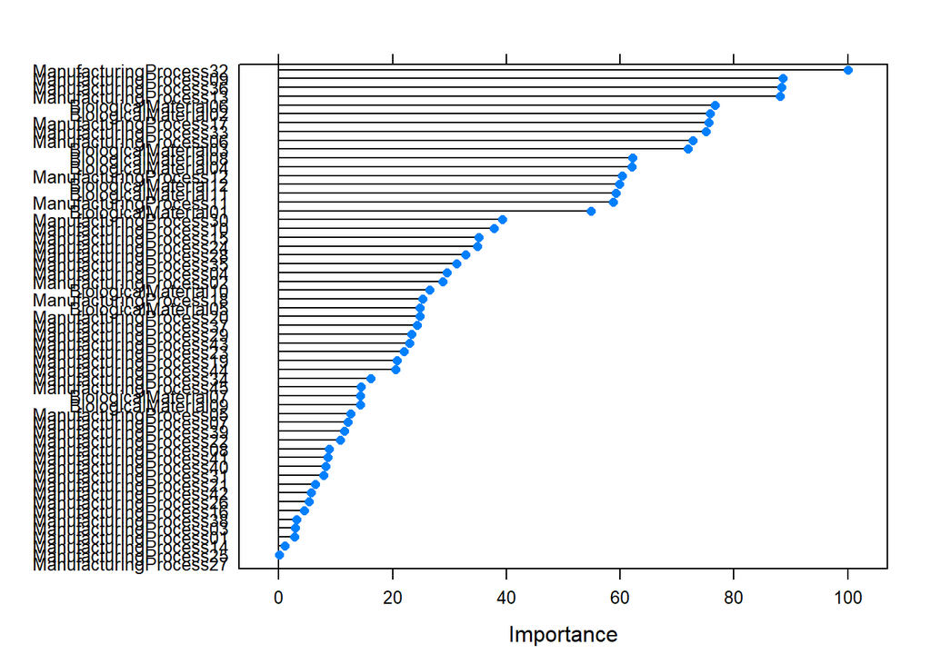

```r
plot(varImp(pls_model))
```

```r
v_imp <- varImp(pls_model)
v_imp
```

```
## pls variable importance
##
##   only 20 most important variables shown (out of 57)
##
##                        Overall
## ManufacturingProcess32  100.00
## ManufacturingProcess09   88.61
## ManufacturingProcess36   88.38
## ManufacturingProcess13   88.07
## BiologicalMaterial06     76.64
## BiologicalMaterial02     75.84
## ManufacturingProcess17   75.61
## ManufacturingProcess33   75.12
## ManufacturingProcess06   72.72
## BiologicalMaterial03     71.89
## BiologicalMaterial08     62.22
## BiologicalMaterial04     62.10
## ManufacturingProcess12   60.34
## BiologicalMaterial12     59.91
## BiologicalMaterial11     59.27
## ManufacturingProcess11   58.71
## BiologicalMaterial01     54.83
## ManufacturingProcess30   39.32
## ManufacturingProcess10   37.88
## ManufacturingProcess15   35.09
```

#### We can see that top predictors are manufacturing processes. So manufatucring processes have much higher impact on target.

#### (f) Explore the relationships between each of the top predictors and the response. How could this information be helpful in improving yield in future runs of the manufacturing process?

#### Lets consider the top 3 predictors and plot them against our target variable.

#### 1. ManufacturingProcess32

#### 2. ManufacturingProcess09

#### 3. ManufacturingProcess36

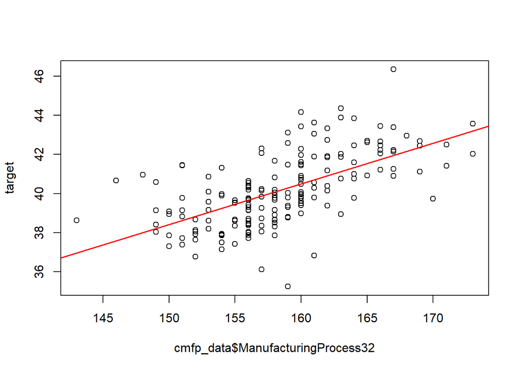

```r
#ManufacturingProcess32
plot(cmfp_data$ManufacturingProcess32, target)
abline(lm(target~cmfp_data$ManufacturingProcess32),col="red",lwd=1.5)
```

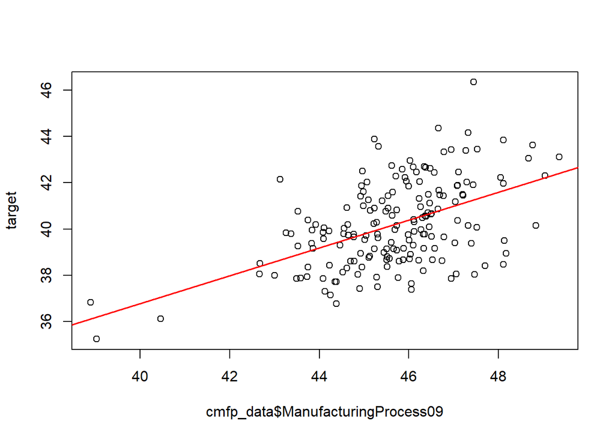

```r
#ManufacturingProcess09
plot(cmfp_data$ManufacturingProcess09, target)
abline(lm(target~cmfp_data$ManufacturingProcess09),col="red",lwd=1.5)
```

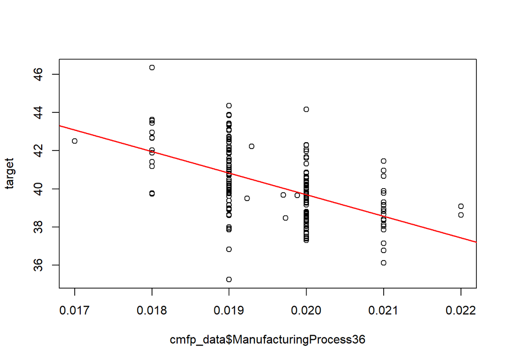

```r
#ManufacturingProcess36
plot(cmfp_data$ManufacturingProcess36, target)
abline(lm(target~cmfp_data$ManufacturingProcess36),col="red",lwd=1.5)
```

#### ManufacturingProcess32 and ManufacturingProcess09 has a positive corelation with the target and ManufacturingProcess36 have negative corelation with the target. This means we could adjust the variables to potentially increase the yield.